# MonteCarlo slides

## Método Monte-Carlo

Sea $f$ una función de densidad de probabilidad y $h\, : \, \mathbb{R} \rightarrow \mathbb{R}$ tales que nos interesa calcular

$$ \mathbb{E}[h(X)] $$

con $X\sim \mathcal{L}(f)$.

Si podemos generar simulaciones $X_1,\ldots , X_n \stackrel{\text{i.i.d.}}{\sim}\mathcal{L}(f)$ entonces podemos usar la Ley Fuerte de los Grandes Número para aproximar

$$ \hat{h}_n=\frac{1}{n}\sum_{i=1}^n h(X_i) \approx \mathbb{E}[h(X)] $$

Aún más, si $\mathbb{E}[h^2(X)]<\infty$ entonces

$$ \hat{s}^2_n = \frac{1}{n} \sum_{i=1}^n \left( h(X_i) - \hat{h}_n \right)^2 \approx \text{Var}\left( h(X) \right) $$

Por el Teorema del Límite Central y el Teorema de Slutsky

$$ \frac{\sqrt{n}\left( \hat{h}_n-\mathbb{E}[h(X)] \right) }{\hat{s}_n} \stackrel{d}{\rightarrow} Z\sim \text{Normal}(0,1) $$

Denotamos $z_\alpha$ al $\alpha$-cuantil de la distribución normal estándar, es decir $\Phi(z_\alpha)=\mathbb{P}[Z\leq z_\alpha]=\alpha $ entonces

$$ \lim_{n\to \infty } \mathbb{P}\left[ z_{\alpha/2} < \frac{ \sqrt{n}\left( \hat{h}_n - \mathbb{E}[h(X)] \right)}{\hat{s}_n} < z_{1-\alpha/2} \right] = \Phi(z_{1-\alpha/2})-\Phi(z_{\alpha/2})=1-\alpha/2 -\alpha/2 = 1-\alpha $$

Equivalentemente consideramos el intervalo

$$ I_\alpha = \left( \hat{h}_n - \frac{ z_{1-\alpha/2}\hat{s}_n}{\sqrt{n}} \, , \, \hat{h}_n - \frac{ z_{\alpha/2}\hat{s}_n}{\sqrt{n}} \right) \stackrel{\text{def.}}{=} \hat{h}_n \stackrel{+}{-} \frac{ z_{1-\alpha/2}\hat{s}_n}{\sqrt{n}} $$

tal que $\mathbb{P}\left[ \mathbb{E}[h(X)] \in I_\alpha \right]=1-\alpha$. Por ejemplot para $\alpha =0.05$, $z_{97.5\%}=-z_{2.5\%}=1.96$ se tiene el intervalo $\hat{h}_n \stackrel{+}{-} \frac{ 1.96\hat{s}_n}{\sqrt{n}}$.

### Ejemplo

Sean $U_1, U_2 \stackrel{\text{i.i.d.}}{\sim} \text{Uniforme}(0,1)$ entonces

$$ \mathbb{E} \left[ 4\mathbb{1}_{ \left\{ U_1^2 + U_2^2 \leq 1 \right\} } \right] = \pi.$$

La indicadora en la ecuación anterior define una variable aleatoria Bernoulli con varianza $2.7$ por lo que usando simulaciones Monte-Carlo para obtener obtener el primer dígito de $\pi$, '3', el $95\%$ de las veces que se simula se necesita un número de iteraciones $n\approx (1.96)^2(2.7^2)/(0.5)^2\approx 112$ y así sucesivamente para más dígitos.

```julia
n1 = 1.96^2.0 * 2.7^2 / 0.5^2.0
```

```
112.021056
```

```julia
n2 = 1.96^2.0 * 2.7^2 / 0.05^2.0
```

```
11202.105599999997
```

```julia
n3 = 1.96^2.0 * 2.7^2 / 0.005^2.0
```

```
1.12021056e6
```

```julia
(-sin(π/4),cos(π/4))
```

```
(-0.7071067811865475, 0.7071067811865476)
```

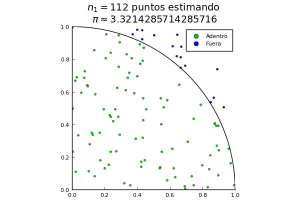

```julia
plot(p)
```

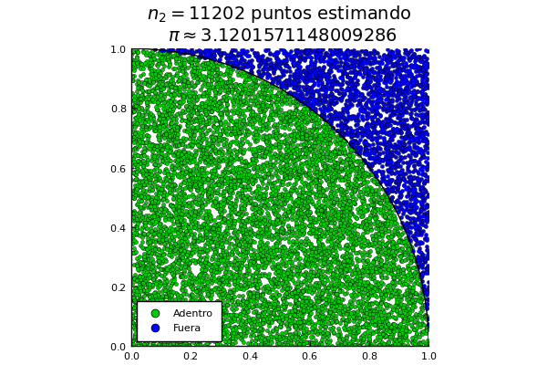

```julia
plot(p)
```

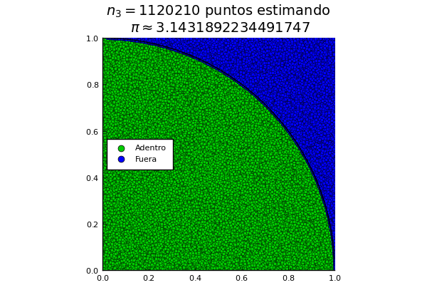

```julia
plot(p)
```

## La maldición de la dimensionalidad

Consideramos el mismo experimento Monte-Carlo para simular $\pi$ variando la dimensión $d$ del espacio donde generamos variables aleatorias uniformes en un hyper-cubo restringidas ahora a una hyper-esfera.

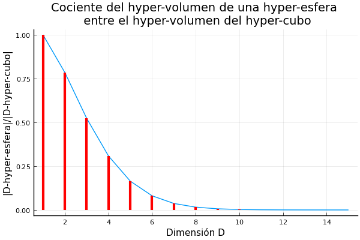

```julia
plot(p)
```

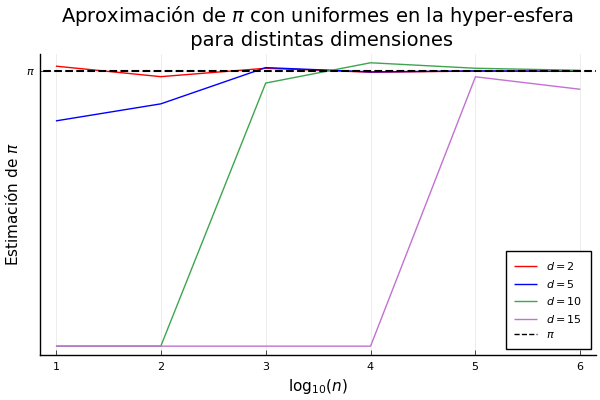

```julia
plot(p)
```

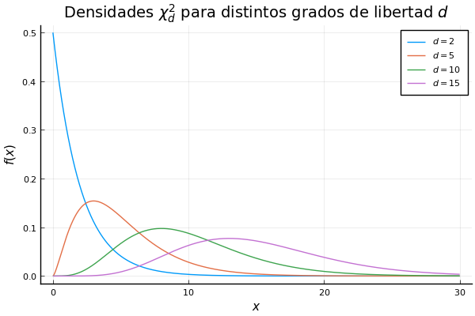

```julia
plot(p)
```

# Reducción de varianza para métodos Monte-Carlo

## Variables antitéticas

En vez de considerar variables aleatorias independientes idénticamente distribuidas (i.i.d.) $X_1, \ldots , X_n$ consideramos variables dpendientes por pares con correlación negativa tales que

$$ (X_1,X_2),\ldots , (X_{n-1},X_n) $$

son $m=n/2$ vectores i.i.d. tales que $X_1,\ldots , X_n$ son idénticamente distribuidos.

Supongamos que $\sigma^2=\text{Var}(X_1)$ y consideremos el estimador Monte-Carlo para la media $\mu=\mathbb{E}[X_1]$

$$ \hat{z}_{Ant} = \frac{X_1 + \ldots + X_n }{n} $$

con varianza

\begin{align*} \frac{\sigma^2_{Ant}}{n} &= \text{Var}\left( \frac{X_1+\ldots +X_n}{2m} \right)= \frac{m}{m^2}\text{Var}\left( \frac{X_1+X_2}{2} \right)=\frac{1}{4m}\left( 2\text{Var}(X_1)+2\text{Cov}(X_1,X_2) \right) \\ & = \frac{1}{2m}(\sigma^2 + \sigma^2\rho)=\frac{\sigma^2}{n}(1 +\rho) \end{align*}

con $\rho= \text{Corr}(X_1,X_2)=\frac{\text{Cov}(X_1,X_2)}{\sqrt{\text{Var}(X_1)\text{Var}(X_2)}}=\frac{\text{Cov}(X_1,X_2)}{\sigma^2}$. Por lo que es deseable que $\rho$ sea lo más cercano posible a $-1$.

Una elección usual al tratar con variables Uniformes$(0,1)$ es considerar vectores $(U,1-U)$ con $U\sim\text{Uniforme}(0,1)$. Por ejemplo si consideramos

$$ \mathbb{E}\left[ \exp\left(U^2\right) \right] = \int_0^1 e^{x^2}\mathrm{d}x $$

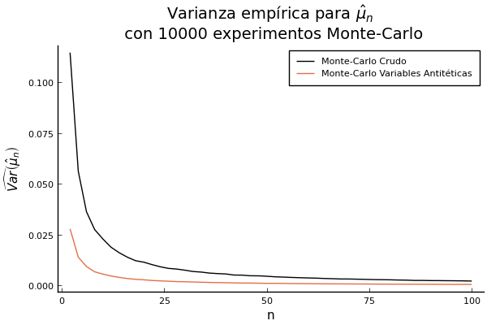

```julia
plot(p)
```

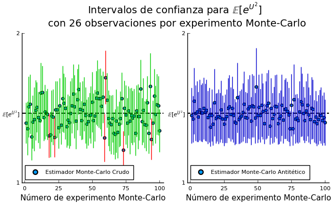

```julia
plot(p_t)
```

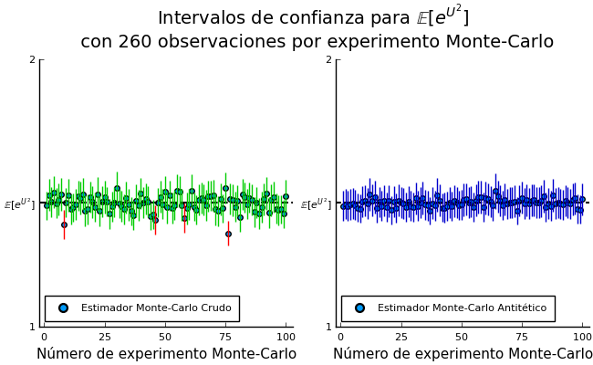

```julia
p_t = plot(title,p,p_a, layout = @layout([A{0.01h}; [B C]]), size=(650,400))
```

### Variables de Control

Ahora consideramos

$$ (X_1,W_1),\ldots , (X_n,W_n) $$

i.i.d. tales que $w=\mathbb{E}[W_1]$ es cocnocida. Concideramos el estimador

$$ \hat{X}_n + \alpha( \hat{W}_n - w ) $$

con $\hat{X}_n=\frac{1}{n}\sum_{i=1}^nX_i$ y $\hat{W}_n=\frac{1}{n}\sum_{i=1}^nW_i$. Claramente

$$ \mathbb{E}\left[ \hat{X}_n + \alpha( \hat{W}_n - w ) \right] = \mathbb{E}[X] $$

Por otro lado

$$ \text{Var}\left( \hat{X}_n + \alpha( \hat{W}_n - w ) \right) = n^{-1}\left( \text{Var}(X_1)+\alpha^2\text{Var}(W_1)+2\alpha\text{Cov}(X_1,W_1) \right) $$

Esta varianza es minimizada con $\alpha=-\frac{\text{Cov}(X_1,W_1)}{\text{Var}(W_1)}$ con lo que se obtiene una varianza de

$$ n^{-1}\left( \text{Var}(X_1)+\frac{\text{Cov}(X_1,W_1)^2}{\text{Var}(W_1)}- 2\frac{\text{Cov}(X_1,W_1)^2}{\text{Var}(W_1)} \right)=n^{-1}\text{Var}(X_1)(1-\rho^2) $$

por lo que necesitamos que la correlación $\rho=\text{Corr}\left( X_1,W_1\right)$ sea lo más cercana a 1 en valor absoluto. En prática tomamos

$$ \hat{\alpha}_n= -\frac{ \frac{1}{n-1}\sum_{i=1}^n(X_i-\hat{X}_n)(W_i-\hat{W}_n) }{ \frac{1}{n-1}\sum_{i=1}^n (W_i-\hat{W}_n)^2 } $$

Observemos que dado un control $W_1$ si consideramos $a+bW_1$ con $a,b\in\mathbb{R}$ tales que $b\neq 0$ entonces

$$ \mathbb{E}\left[ \hat{X}_n + \alpha( a+b\hat{W}_n - a -bw ) \right] = \mathbb{E}[X] $$

y

$$ \frac{\text{Cov}(X_1,a+bW_1)^2}{\text{Var}(a+bW_1)}=\frac{\text{Cov}(X_1,W_1)^2}{\text{Var}(W_1)} $$

por lo que el control $a+bW_1$ consigue la misma reducción de varianza sin alterar sus estimación Monte-Carlo.

### Ejemplo

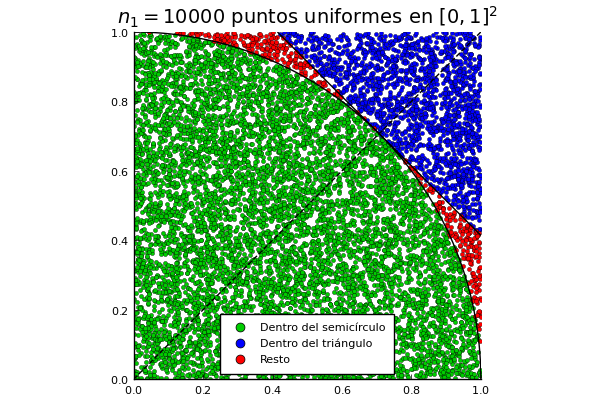

```julia
plot(p)
```

```julia
m = 10000
x = rand(Uniform(0,1),m)
y = rand(Uniform(0,1),m)
p_v = [ 4.0*( x[i]^2 + y[i]^2 <= 1.0) for i in 1:m]
p_v_c = [ 1.0*( x[i] + y[i] <= sqrt(2.0)) for i in 1:m]
α = - sum( ( p_v .- mean(p_v) ) .* ( p_v_c .- mean(p_v_c) ) )/sum( ( p_v_c .- mean(p_v_c) ).^2.0 )
ρ = sum( ( p_v .- mean(p_v) ) .* ( p_v_c .- mean(p_v_c) ) )/sqrt(sum( ( p_v .- mean(p_v) ).^2.0 )*sum( ( p_v_c .- mean(p_v_c) ).^2.0 ))
p_v_n = p_v .+ α.*( p_v_c .- ( 1.0 -  0.5*(2.0-sqrt(2))^2.0 ) );
```

```julia
# Sin variables de control
var(p_v)
```

```
2.774385598559852
```

```julia
# Con variables de control
var(p_v_n)
```

```
0.6706258739380208
```

```julia
var(p_v)*(1-ρ^2)
```

```
0.670625873938021
```

## Monte-Carlo condicional o Rao-Blackwellización

Recordemos que si $X,W$ son variables aleatorias entonces

$$ \text{Var}\left( X \right) = \text{Var}\left( \mathbb{E}[X\,|\,W] \right) + \mathbb{E}[\text{Var}\left(X\,|\, W \right)]. $$

De lo que se sigue que

$$ \text{Var}\left( X \right) \geq \text{Var}\left( \mathbb{E}[X \,|\,W] \right), $$

por lo que podemos simular $\mathbb{E}[X \, | \, W]$ para realizar estimaciones Monte-Carlo de $\mathbb{E}\left[ \mathbb{E}[X\, | \, W] \right]=\mathbb{E}[X]$ obteniendo una reducción de varianza en comparación de la estimación Monte-Carlo obtenida de utilizar simulaciones de $X$.

### Ejemplo

Nuevamente consideramos $\left(U_1,U_2\right)$ uniforme en $[0,1]\times[0,1]$ y $X=4\mathbb{1}\left\{ U_1^2 + U_2^2 \leq 1 \right\}$ para estimar $\pi=\mathbb{E}[X]$. Si condicionamos a $X$ respecto de $U_1$ obtenemos

$$ X_{\text{cond}}=\mathbb{E}\left[ X \, | \, U_1 \right]=4\mathbb{P}\left[ U_1^2 + U_2^2 \leq 1 \, | \, U_1 \right] =4\mathbb{P}\left[ U_2 \leq \sqrt{1 - U_1^2} \, \big| \, U_1 \right]=4\sqrt{1 - U_1^2} $$

```julia
# Sin condicionar
var(p_v)
```

```
2.772613261326134
```

```julia
# Sin condicionar
mean(p_v)
```

```
3.108
```

```julia
# Condicionando
var(p_cond)
```

```
0.8219007950507617
```

```julia
# Condicionando
mean(p_cond)
```

```
3.131212898485202
```

## Monte-Carlo estratificado

Consideramos estratos $\Omega_s$ tales que $\cup_{s=1}^Ŝ \Omega_s=\Omega$ con $\Omega$ el espacio donde toma valores el elemento aleatorio que estemos simulando. Por simplicidad supongamos que $\Omega=[0,1]$ y simulamos $U\sim\text{Uniforme}$ para definir $X=g(U)$ con $g\, : \, [0,1]\rightarrow \mathbb{R}$. Denotamos $\Omega_s=\left\{ \omega \, : \, \frac{s-1}{S} \leq U(\omega) < \frac{s}{S} \right\}$ para $s\in\left\{ 1,\ldots, S\right\}$; entonces podemos definir $X_s$ como $X$ restringido a $\Omega_s$ dada por la ley de probabilidad

$$ \mathbb{P}[X_s \in C]=\frac{ \mathbb{P}[ \{ X_s \in C \} \cap \Omega_s] }{\mathbb{P}[\Omega_s]} $$

Sea $p_s=\mathbb{P}[\Omega_s]$ entonces $\mathbb{E}[X]=\sum_{s=1}^S p_s\mathbb{E}[X_s]$. Por lo que podemos considerar $R_s$ simulaciones para cada variable estratificada $X_s$ y estimar

$$ \hat{X}_{\text{Estrat}} = \sum_{s=1}^S p_s \hat{X}_s $$

Con $R=\sum_{i=1}^S R_s $ y $\sigma^2_s=\text{Var}(X_s)$ definimos la varianza

$$ \sigma^2_{\text{Estrat}}=R\text{Var}(\hat{X}_{\text{Estrat}})= R \sum_{i=1}^S p_s^2 \frac{\sigma^2_s}{R_s}= \sum_{s=1}^S p_s^2 \frac{\sigma^2_s}{R_s/R} $$

Con lo que $$\frac{\sqrt{R}}{\sigma_{\text{Estrat}}}(\hat{X}_{\text{Estrat}}-\mathbb{E}[X])\rightarrow \text{Normal}(0,1)$$

cuando $R_s/R$ tiene un límite distinto de cero cuando $R\to \infty$.

Si $p_s=R_s/R$, lo que llamamos $\textit{estratificado de alocación proporcional}$ entonces $$ \sigma^2_{\text{Estrat}}=\sum_{s=1}^S p_s \sigma^2_s. $$

Observemos que si $J$ es una variable aleatoria discreta definida por $\mathbb{P}[J=s]=p_s$ entonce $X_J \stackrel{d}{=} X$ por construcción y

$$ \sigma^2 = \text{Var}(X) = \text{Var}(X_J) \geq \mathbb{E}[\text{Var}(X_J|J)]=\sigma^2_{\text{Estrat}}. $$

Por lo que con estratificado de alocación proporcional la varianza nunca aumenta.

Para estratificado de alocación proporcional la varianza puede ser estimada por

$$ \sigma^2_{\text{Estrat}}= \sum_{s=1}^S p_s \sigma^2_s \approx \sum_{s=1}^S p_s \hat{\sigma}^2_s=\hat{\sigma}^2_{\text{Estrat}} $$

donde $\hat{\sigma}^2_s$ es la varianza estimada en el estrato $s$.

```julia
# Sin estratificar
var(4 .* p_v_estrat)
```

```
2.7619523552355267
```

```julia
mean(p_v)
```

```
3.1072
```

```julia
# Estratificado
estrat_var(m,s,x,y)
```

```
0.2323341422932304
```

```julia
estrat_mean(m,s,x,y)
```

```
3.14160945433067
```

Es de interés estimar el orden de magnitud de la varianza reducida. En el caso anterior para estimar $\pi$ hicimos uso de $S=S_0^2$ estratos dados por

$$ \Omega_{i,j} = \left\{ \frac{i-1}{S_0} \leq U_1 < \frac{i}{S_0}, \, \frac{j-1}{S_0} \leq U_2 < \frac{j}{S_0} \right\} $$

por lo que $p_s=1/S_0^2$ para el estratificado de alocación proporcional. Por otro lado $\hat{\sigma}^2_s$ es distinto de cero en $\mathcal{O}(S_0)$ estratos por lo que $\sigma^2_{\text{Estr}}\in \mathcal{O}(S_0S_0^{-2})=\mathcal{O}(S_0^{-1})=\mathcal{O}(S^{-1/2})$.

Supongamos que queremos estimar $\int_0^1 g(x)\mathrm{d}x$ para $g\, : \, [0,1]\rightarrow \mathbb{R}$ usando los estratos $\Omega_s=\left\{ \omega \, : \, \frac{s-1}{S} \leq U(\omega) < \frac{s}{S} \right\}$ para $s\in\left\{ 1,\ldots, S\right\}$ con alocación proporcional $p_s=\frac{1}{S}$. Entonces

$$ \sigma^2_s = \text{Var}\left( g(U) \, \bigg|\frac{s-1}{S} \leq U <\frac{s}{S} \right) = \text{Var}\left(g\left( \frac{s-1}{s} + \frac{U}{S} \right) \right) = \text{Var}\left(g\left( \frac{s-1}{s} \right) + \frac{h(s,S,U)}{S} \right) =\text{Var}\left( \frac{h(s,S,U)}{S} \right) $$

con $h(s,S,x)=S\left( g\left( \frac{s-1+x}{S} \right) - g\left( \frac{s-1}{S} \right) \right)$. Si $g$ es suficientemente suave entonces $c=sup_{x\in [0,1]} |h(s,S,x)|\leq || g'||_\infty$ uniformemente en $s,S$ con lo que $\sigma^2_s \leq c^2/S^2$ y

$$ \sigma^2_{\text{Estr}}=\sum_{s=1}^S S^{-1}\mathcal{O}(S^{-2}) = \mathcal{O}(S^{-2}). $$

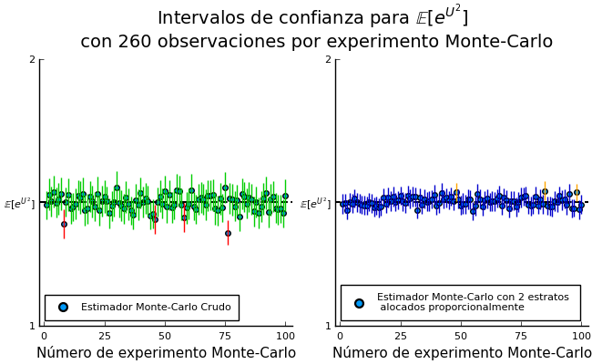

```julia
plot(p_t)
```

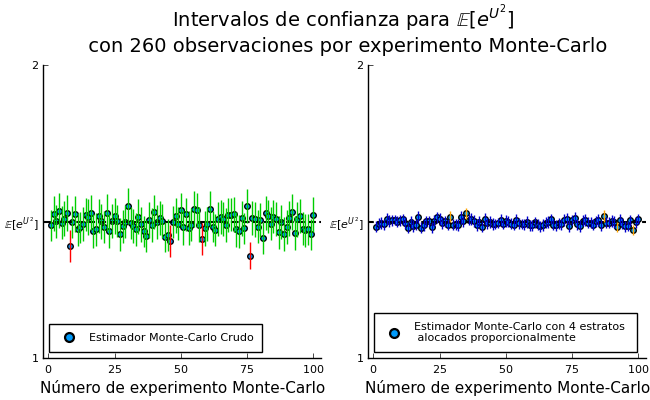

```julia
plot(p_t)
```

## Muestreo por importancia

Sea $f$ una densidad de probabilidad asociada a una variable aleatoria que toma valores en $\mathbb{R}$ y $h\, : \, \mathbb{R} \rightarrow \mathbb{R}$ una función tal que nos interesa estimar

$$ \mathbb{E}_f[h(X)] $$

donde usamos el subíndice $f$ para enfatizar que $X\sim\mathcal{L}(f)$.

Consideramos una distribución de probabilidad auxiliar de la cual podemos realizar simulaciones y que tenga asociada una función de densidad de probabilidad $g$ tal que $\text{supp}(f)\subset \text{supp}(g)$. Entonces

$$ \mathbb{E}_f\left[h(X)\right] = \int h(x)f(x) \mathrm{d}x =\int \frac{h(x)f(x)}{g(x)}g(x) \mathrm{d}x = \mathbb{E}_g\left[ \frac{h(X)f(X)}{g(X)}\right] \approx \frac{1}{n} \sum_{i=1}^n \frac{h(X_i)f(X_i)}{g(X_i)}, \; \text{ con } X_i\sim\mathcal{L}(g),\quad i\in\left\{1,\ldots , n \right\} $$

Consideremos un ejemplo donde el muestreo por importancia es beneficioso. Sean $X_1,\ldots , X_n \stackrel{\text{i.i.d.}}{\sim}\text{Normal}(0,1)$ entonces

$$ \frac{1}{n} \sum_{i=1}^n \mathbb{1}\left\{ -1 \leq X_i \leq 1 \right\} \approx \mathbb{P}[X_1\in[-1,1]]=\Phi(1)-\Phi(-1) $$

```julia
cdf(Normal(),1)-cdf(Normal(),-1)
```

```
0.6826894921370861
```

```julia
X = randn(100000)
indic(x) = 1.0*( -1 <= x <= 1 )
mean(indic.(X))
```

```
0.68255
```

Por otro lado

$$ \frac{1}{n} \sum_{i=1}^n \mathbb{1}\left\{ 4.5 \leq X_i \right\} \approx \mathbb{P}[X_1\in[-1,1]]=1-\Phi(4.5) $$

está asociada a un evento con muy baja probabilidad por lo que una aproximación de Monte-Carlo puede requerir un gran número de simulaciones para realizar una buena estimación.

```julia
1-cdf(Normal(),4.5)
```

```
3.3976731247387093e-6
```

```julia
X = randn(100000)
indic(x) = 1.0*( 4.5 <= x )
mean(indic.(X))
```

```
0.0
```

Podemos considerar muestreo por importancia utilizando una variable exponencial estándar restringida a $[4.5,\infty)$. Tal variable aleatoria tiene función cumulativa de probabilidad

$$ G(x)=\frac{e^{-4.5}-e^{-x}}{e^{-4.5}}\mathbb{1}\left\{ 4.5 \leq x \right\} $$

de lo que se sigue que para $-\log(e^{-4.5}U)=-log(U)+4.5\sim \mathcal{L}(G)$ con $U\sim \text{Uniforme}(0,1)$ .

```julia
Y = rand(Exponential(),100000) .+ 4.5
fsobreg(x) = pdf(Normal(),x)/(exp(4.5-x))
mean(fsobreg.(Y))
```

```
3.397021997894572e-6
```

```julia
1-cdf(Normal(),4.5)
```

```
3.3976731247387093e-6
```

El muestreo por importancia puede ser visto como un cambio de medida. Supongamos que tenemos dos medidas de probabilidad $\mathbb{P}$, $\tilde{\mathbb{P}}$ en $(X,\mathcal{X})$ tal que $\forall A\in \mathcal{X}$, la $\sigma$-álgebra correspondiente,

$$ \mathbb{P}[A]=0 \implies \tilde{\mathbb{P}}[A]=0. $$

Decimos en tal caso que $\mathbb{P}$ es absolutamente continua respecto a $\tilde{\mathbb{P}}$ y lo denotamos como $\tilde{\mathbb{P}}[A]<<\mathbb{P}[A]$. El teorema de Radón-Nikodym nos dice que si $\tilde{\mathbb{P}[A]}<<\mathbb{P}[A]$ entonces existe una variable aleatoria $L$ tal que

$$ \mathbb{1}\left\{ Z(\omega) \neq 0 \right\}\mathbb{P}(\mathrm{d}\omega) = \mathbb{1}\left\{ Z(\omega) \neq 0 \right\}L(\omega)\tilde{\mathbb{P}}(\mathrm{d}\omega). $$

Se sigue que

$$ \mathbb{E}_{\mathbb{P}}[Z] = \mathbb{E}_{\tilde{\mathbb{P}}}[LZ]. $$

A la variable aleatoria $L$ se le llama la derivada de Radón-Nikodym de $\mathbb{P}$ con respecto a $\tilde{\mathbb{P}}$ denotada $\frac{\mathrm{d}\mathbb{P}}{\mathrm{d}\tilde{\mathbb{P}}}$.

Consideramos en particular $X\sim \mathcal{L}(\mathbb{P})=\mathcal{L}(f)$ con $f$ una densidad de probabilidad definida en $\mathbb{R}$ y $Z=h(X)$ con $h\, : \, \mathbb{R} \rightarrow \mathbb{R}$.Supongamos que se tiene una segunda ley de probabilidad $\mathcal{L}(\tilde{\mathbb{P}})=\mathcal{L}(\tilde{f})$ tal que $\tilde{f}$ es una densidad de probabilidad en $\mathbb{R}$ con el mismos soporte que $f$. Entonces

$$ \mathbb{E}_{\mathbb{P}}[h(X)]= \int_\mathbb{R}h(x)f(x)\mathrm{d}x = \int_\mathbb{R}h(x)\frac{f(x)}{\tilde{f}(x)}\tilde{f}(x)\mathrm{d}x =\mathbb{E}_{\tilde{\mathbb{P}}}\left[h(X)\frac{f(X)}{\tilde{f}(X)}\right] $$

Por lo que $L=\frac{f(X)}{\tilde{f}(X)}$ es la la derivada de Radón-Nikodym de $\mathbb{P}$ con respecto a $\tilde{\mathbb{P}}$; la cual es utilizada en el muestreo por importancia.

### Teorema

Sea $\mathbb{P}^*$ definida por

$$ \frac{\mathrm{d}\mathbb{P}^*}{\mathrm{d}\mathbb{P}}=\frac{|Z|}{\mathbb{E}_{\mathbb{P}}\left[ |Z| \right]},\, \text{ es decir } \; \mathbb{P}^* \mathrm{d}(\omega) = \frac{|Z|}{\mathbb{E}_{\mathbb{P}}\left[ |Z| \right]} \mathbb{P}(\mathrm{d}\omega) $$

con lo que $L^* = \frac{\mathbb{E}_{\mathbb{P}}\left[ |Z| \right]}{|Z|}$. Entonces $ZL^*$ tiene menor varianza bajo $\mathbb{P}^*$ que $ZL$ bajo $\tilde{\mathbb{P}}$, con $L=\frac{\mathrm{d}\mathbb{P}}{\mathrm{d}\tilde{\mathbb{P}}}$.

Para el caso particular de muestreo por importancia tenemos

### Teorema

La elección de $g$ que minimiza la varianza de $$ \mathbb{E}_g\left[ \frac{h(X)f(X)}{g(X)} \right] $$

está dada por

$$ g^\star (x) = \frac{|h(x)|f(x)}{\int |h(x)|f(x)\mathrm{d}x}. $$

Observemos que $$\text{Var}_g \left( \frac{h(X)f(X)}{g(X)} \right)<\infty$$ si sólo si

$$ \mathbb{E}_g\left[ \frac{h^2(X)f^2(X)}{g^2(X)} \right] = \mathbb{E}_f\left[ \frac{h^2(X)f(X)}{g(X)} \right] = \int h^2(x)\frac{f^2(x)}{g(x)}\mathrm{d}x<\infty $$

Aunque no es necesaria la hipótesis de varianza finita para la convergencia del estimador de Monte-Carlo por importancia; la estimación suele ser pobre cuando

$$ \int \frac{f^2(x)}{g(x)}\mathrm{d}x =\infty $$

En particular se recomienda que $f/g$ sea acotado, es decir $f\in\mathcal{O}(g)$ con lo que la colas de $g$ son más pesadas que las de $f$.

### Muestreo por importancia normalizado

Observemos que si $Mf=f_{ker}$ es conocido más no $f=f/\left(\int f_{ker}(x)\mathrm{d}x\right)$, tal puede ser el caso si no se conoce la constante de normalización de $f$. Entonces por el Teorema de Slutsky podemos usar el siguiente estimador de Monte-Carlo

$$ \mathbb{E}_f\left[h(X)\right] \stackrel{\text{c.s.}}{\approx} \frac{ \frac{1}{n}\sum_{i=1}^n \frac{h(X_i)f_{ker}(X_i)}{g(X_i)}}{ \frac{1}{n} \sum_{i=1}^n \frac{f_{ker}(X_i)}{g(X_i)}}, \; \text{ con } X_i\sim\mathcal{L}(g) $$

### Aproximación de Laplace

La aproximación de Laplace es un método determinista analítico para aproximar una integral. En particular supongamos que queremos estimar

$$ \int_{-\infty}^\infty e^{-cf(x)} \mathrm{d}x $$

Si suponemos que se puede realizar la siguiente expansión de Taylor para $f$ alredor de $x_0$

$$ f(x) = f(x_0) + f'(x_0)(x-x_0) + \frac{1}{2}f''(x_0)(x-x_0)^2 + R $$

con $R\in \mathcal{O}\left((x-x_0)^3\right)$. Si más áun suponemos que $x_0$ tiene un mínimo global en $(a,b)$ entonces

$$ f(x) \approx f(x_0) + \frac{1}{2}f''(x_0)(x-x_0)^2 $$

y

$$ \int_{-\infty}^\infty e^{-cf(x)} \mathrm{d}x \approx e^{-cf(x_0)} \int_{-\infty}^\infty e^{- \frac{c}{2}|f''(x_0)|(x-x_0)^2}\mathrm{d}x = e^{-cf(x_0)}\sqrt{\frac{2\pi}{cf''(x_0)}} $$

Lo cual es como aproximar la integral usando el kernel de una densidad gaussiana con media $x_0$ y varianza $1/|f''(x_0)|$.

En particular haremos uso de

$$ x_0 + \sqrt{\frac{1}{|f''(x_0)|}}T, $$

con $T$ una variable aleatoria $t$ con d-grados de libertad, para usar como distribución de importancia.

### Ejemplo

Consideramos el modelo de regresión logística

\begin{align*} Y_i \, | \, \beta & \sim \text{Bernoulli}\left( \frac{e^{\beta x_i}}{1+e^{\beta x_i}} \right), \; i\in\left\{1,\ldots ,n \right\} \\ \beta & \sim \text{Normal}(0,\sigma^2) \end{align*}

Dadas observaciones $Y_1=y_1,\ldots , Y_n=y_n$, tenemos la verosimilitud

$$ p(\pmb{y},\beta)=\frac{1}{\sqrt{2\pi\sigma^2}}e^{-\frac{\beta^2}{2\sigma^2}} \prod_{i=1}^n \left( \frac{ e^{x_i\beta}}{1+e^{x_i\beta}} \right)^{y_i} \left( \frac{ 1 }{1+e^{x_i\beta}} \right)^{1-y_i} $$

por lo que \begin{align*} log(p(\pmb{y},\beta)) & = -0.5\log(2\pi\sigma^2) - \frac{\beta^2}{2\sigma^2} + \sum_{i=1}^n y_i x_i\beta - y_i\log(1+e^{x_i\beta}) - (1- y_i)\log(1+e^{x_i\beta}) \\ & = -0.5\log(2\pi\sigma^2) - \frac{\beta^2}{2\sigma^2} + \sum_{i=1}^n y_i x_i\beta - \log(1+e^{x_i\beta}) \end{align*}

y \begin{align*} \frac{\mathrm{d}}{\mathrm{d}\beta} \log(p(\pmb{y},\beta)) & = - \frac{\beta}{\sigma^2} + \sum_{i=1}^n y_i x_i - \frac{x_i e^{x_i\beta}}{1+e^{x_i\beta}} \\ \frac{\mathrm{d}^2}{\mathrm{d}^2\beta}log(p(\pmb{y},\beta)) & = - \frac{1}{\sigma^2} -\sum_{i=1}^n \frac{x_i^2 e^{x_i\beta}}{(1+e^{x_i\beta})^2} \end{align*}

```julia
m = 300
x =  rand(Normal(0.0,0.5),m)
y = [ rand( Bernoulli( exp(x[i]*0.75)/(1+exp(x[i]*0.75)) ) ) for i in 1:m ];
```

```julia
f(b) = pdf(Normal(),b[1])*prod( [ pdf( Bernoulli( exp(x[j]*b[1])/(1+exp(x[j]*b[1])) ), y[j]) for j in 1:m ] )
norm_c = hcubature(f, [-100], [100])[1]
```

```
2.5105942994657693e-90
```

```julia
post(b) = f(b)/norm_c
```

```
post (generic function with 1 method)
```

```julia
z(β) = sum(y .* x)- sum( x .* [ exp(j*β)/(1+exp(j*β)) for j in x ] ) - β
z(0.5)
```

```
1.2455461852800953
```

```julia
z(1.1)
```

```
-9.46843940152486
```

```julia
β_lap =find_zero(z, (0.5,1.1), Bisection())
```

```
0.5656995680088349
```

```julia
std_lap = 1.0/sqrt(1+sum( x .* x .* [ exp(j*β_lap)/(1+exp(j*β_lap))^2.0 for j in x ] ))
```

```
0.2303486324101292
```

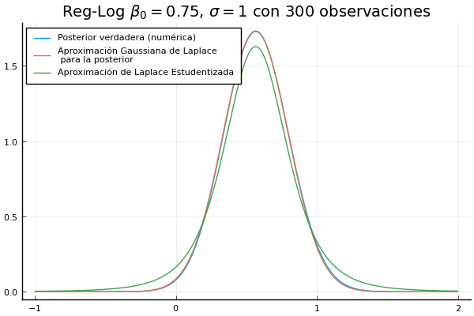

```julia
plot(p)
```

[figure not shown]

```julia
plot(p)
```

[figure not shown]

```julia
plot(p)
```

[figure not shown]

```julia
plot(p)
```

[figure not shown]

```julia
plot(p)
```

```julia
# Probabilidad de masa verdadera
true_mass = [ hcubature(post, [i-0.025], [i+0.025])[1] for i in collect(-1:0.05:2.0) ];
```

```julia
sum( abs.( true_mass .- imp_dens ) )
```

```
0.03224197861064378
```

```julia
sum( abs.( true_mass .- gauss_imp_dens ) )
```

```
0.04579293684147673
```

```julia
# Elección alterna de parámetros
m = 300
σ = 3.1
β₀ = 2.7 # rand(Normal(0,σ))
x =  rand(Normal(0.5,1.0),m)
y = [ rand( Bernoulli( exp(x[i]*β₀)/(1+exp(x[i]*β₀)) ) ) for i in 1:m ];
```

```julia
z(β) = sum(y .* x)- sum( x .* [ exp(j*β)/(1+exp(j*β)) for j in x ] ) - β/σ^2.0
z(2.5)
```

```
1.8836542612837421
```

```julia
z(3.9)
```

```
-8.541189031242642
```

```julia
β_lap =find_zero(z, (2.5,3.9), Bisection())
std_lap = 1.0/sqrt(1/σ^2.0+sum( x .* x .* [ exp(j*β_lap)/(1+exp(j*β_lap))^2.0 for j in x ] ))
```

```
0.3076662623321379
```

```julia
# Posterior de beta obtenida numéricamente
f(b) = pdf(Normal(0,σ),b[1])*prod( [ pdf( Bernoulli( exp(x[j]*b[1])/(1+exp(x[j]*b[1])) ), y[j]) for j in 1:m ] )
norm_c = hcubature(f, [-100], [100])[1]
println(norm_c)
post(b) = f(b)/norm_c
```

```
3.669635831309344e-49
```

```
post (generic function with 1 method)
```

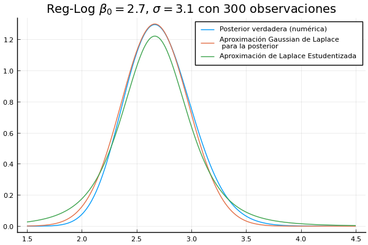

```julia
plot(p)
```

```julia
# Valores de masa de probabilidad verdaderos
true_mass = [ hcubature(post, [i-0.025], [i+0.025])[1] for i in collect(1.5:0.05:4.5) ];
```

```julia
sum( abs.( true_mass .- imp_dens ) )
```

```
0.03547169507501686
```

```julia
sum( abs.( true_mass .- gauss_imp_dens ) )
```

```
0.044987944780702574
```

[figure not shown]

```julia
plot(p)
```

[figure not shown]

```julia
plot(p)
```

### Muestreo por importancia adaptativo

Consideramos una familia de densidades $g$ parametrizadas por un vector $\pmb{\theta}\in \mathbb{R}^d$.

Sea $g_0$ la densidad de importancia inicial determinada por un vector de parámetros $\pmb{\theta}_0$

- Para $j\in\left\{1, \ldots , J \right\}$
  - Simulamos $\pmb{Y}=Y_1,\ldots , Y_n \stackrel{\text{i.i.d.}}{\sim}\mathcal{L}(g_{j-1})$. Y calculamos una aproximación discreta a $f$ la densidad de interés basada en $\pmb{Y}$. Usualmente usamos $$ \tilde{g}_{j-1}(y) = \frac{\sum_{i=1}^n \frac{f(Y_i)}{g_0(Y_i)} \delta_{Y_i}(y) }{\sum_{i=1}\frac{f(Y_i)}{g_0(Y_i)}} $$
  - Actualizamos a $g_j$ dada por $\pmb{\theta}_j$ basado en $\tilde{g}_{j-1}$ (por ejemplo se puede hacer coincidir momentos de $g_j$ y $\tilde{g}_{j-1}$ para elegir $\pmb{\theta}_j$)

```julia
plot(p)
```

[output not shown]

[figure not shown]

```julia
plot(p)
```

[figure not shown]

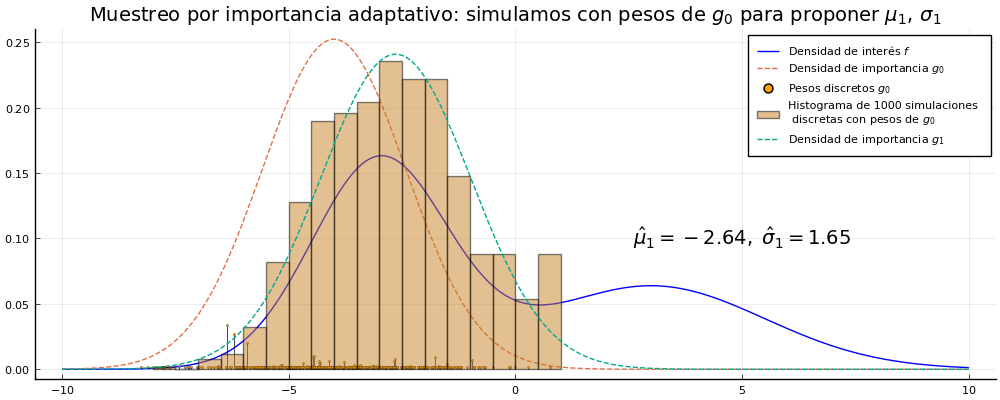

```julia
plot(p)
```

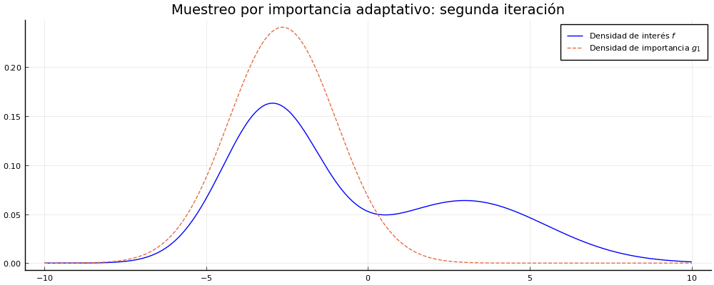

```julia
plot(p)
```

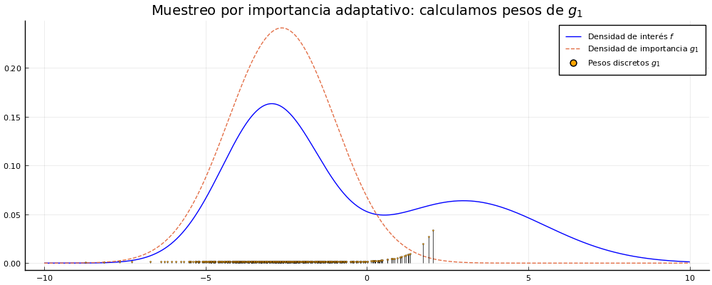

```julia
plot(p)
```

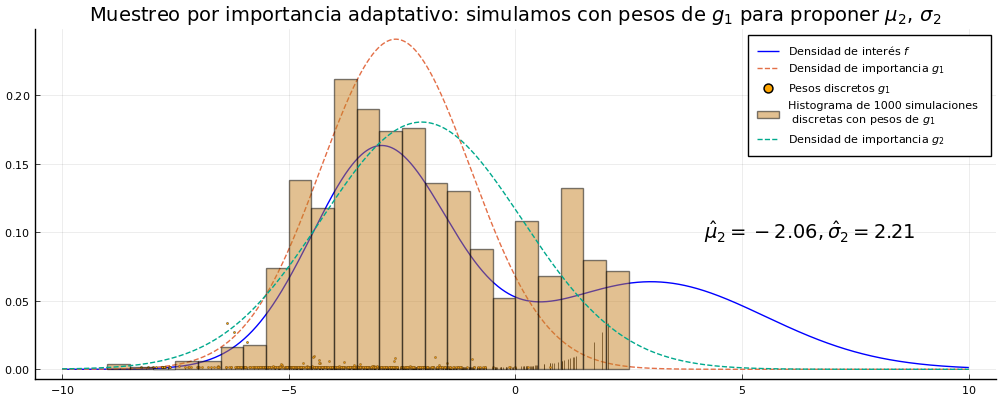

```julia
plot(p)
```

[figure not shown]

```julia
plot(p)
```

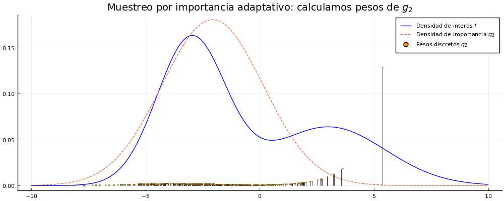

```julia
plot(p)
```

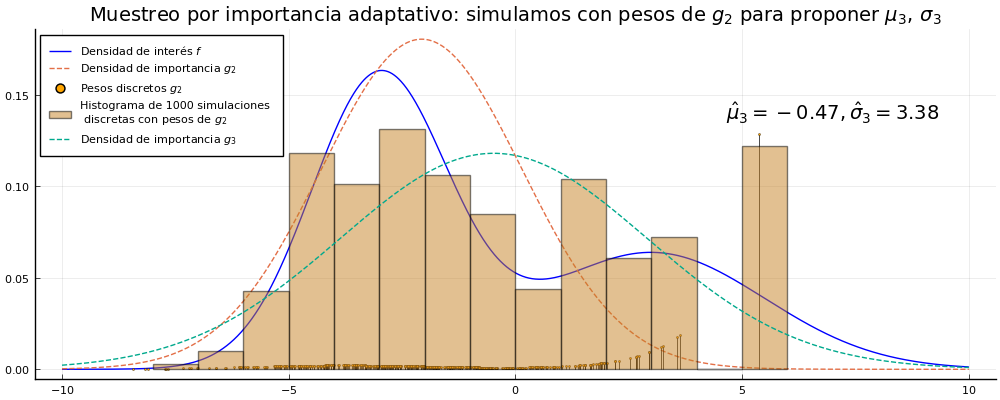

```julia
plot(p)
```

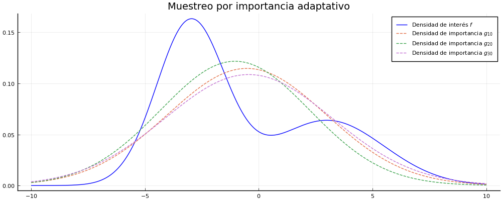

```julia
plot(p)
```